# Practical Machine Learning Project

Diego Alfaro

Saturday, January 24, 2015

# Data Preparation

The first steps I took to solve the project were to load the data files and the libraries that will be used, and additionally to set the seed:

```r
library(caret)
library(rattle)
training <- read.csv("pml-training.csv", header=T)
test <- read.csv("pml-testing.csv", header=T)

set.seed(3262)
```

After loading the data, I realized that I would need to trim it since it was 160 variables wide. Plotting each variable against the *classe* column was a very slow process, and it didn’t yield any useful results so I won’t bother putting the results in here. I also tried reducing columns through PCA, but I kept getting errors that stated that some columns were not numeric.

Although exploring the data didn’t yield any obvious preference for predictors, it did allow me to see that some of the columns were extremely sparse, and that caused R to see them as factors. I proceeded to filter out columns in two steps: 1) Calculate the variance of each column, and then remove those that returned NA. 2) Even after this, some columns were still detected as non-numeric, so I removed those columns where is.numeric(x) returned FALSE. 3) Append the *classe* and *user_name* variables to the reduced training dataset.

This is the code to perform these tasks:

```r
columns <- colnames(training)
colvars <- numeric(length(columns))

for (i in (1:length(colvars)))
{
  colvars[i] <- var(training[,i])
}

reduced.training <- training[!(is.na(colvars))] #89 vars
reduced.training <- reduced.training[,-c(1,3:7)] #remove

columns <- colnames(reduced.training)
col.numeric <- logical(length(columns))

for (i in (1:length(col.numeric)))
{
  col.numeric[i] <- is.numeric(reduced.training[,i])
}

reduced.training <- reduced.training[col.numeric] #53 variables

reduced.training <- cbind(training$classe, training$user_name, reduced.training) #append classe and user_name

colnames(reduced.training)[1] <- "classe"
colnames(reduced.training)[2] <- "user_name"
```

With the reduced dataset, I proceeded to do the split into the training and validation set:

```r
inTrain <- createDataPartition(y=reduced.training$classe, p=0.6, list=F)
train <- reduced.training[inTrain,]
validate <- reduced.training[-inTrain,]
```

# Data Modeling

As part of the assignment specified that we needed to use cross-validation, I specified the control to be 10-fold K Validation:

```r
ctrl <- trainControl(method = "cv", number = 10)
```

I then proceeded to build a first model using desicion trees (rpart algorithm):

```r
modelFit <- train(classe~., method="rpart", data=train, trControl=ctrl)
```

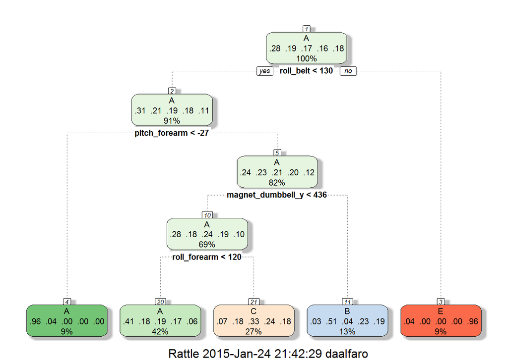

```r
fancyRpartPlot(modelFit$finalModel)
```

This model, however, had a less than ideal accuracy (49% as shown in the confusion matrix below).

```r
predictions <- predict(modelFit, newdata=validate)
confusionMatrix(predictions, validate$classe)
```

```
## Confusion Matrix and Statistics
##
##           Reference
## Prediction    A    B    C    D    E
##          A 1985  651  628  580  202
##          B   45  519   50  234  189
##          C  170  348  690  472  377
##          D    0    0    0    0    0
##          E   32    0    0    0  674
##
## Overall Statistics
##
##                Accuracy : 0.493
##                  95% CI : (0.482, 0.504)
##     No Information Rate : 0.284
##     P-Value [Acc > NIR] : <2e-16
##
##                   Kappa : 0.338
##  Mcnemar's Test P-Value : NA
##
## Statistics by Class:
##
##                      Class: A Class: B Class: C Class: D Class: E
## Sensitivity             0.889   0.3419   0.5044    0.000   0.4674
## Specificity             0.633   0.9181   0.7890    1.000   0.9950
## Pos Pred Value          0.491   0.5005   0.3354      NaN   0.9547
## Neg Pred Value          0.935   0.8533   0.8829    0.836   0.8924
## Prevalence              0.284   0.1935   0.1744    0.164   0.1838
## Detection Rate          0.253   0.0661   0.0879    0.000   0.0859
## Detection Prevalence    0.516   0.1322   0.2622    0.000   0.0900
## Balanced Accuracy       0.761   0.6300   0.6467    0.500   0.7312
```

The second model I built, used random forest and had an accuracy of 99%, as shown below:

```r
modelFit <- train(classe~., method="rf", data=train, trControl=ctrl)
predictions <- predict(modelFit, newdata=validate)
confusionMatrix(predictions, validate$classe)
```

```
## Confusion Matrix and Statistics
##
##           Reference
## Prediction    A    B    C    D    E
##          A 2230   10    0    1    0
##          B    0 1504   19    0    0
##          C    2    4 1347   24    0
##          D    0    0    2 1261   10
##          E    0    0    0    0 1432
##
## Overall Statistics
##
##                Accuracy : 0.991
##                  95% CI : (0.988, 0.993)
##     No Information Rate : 0.284
##     P-Value [Acc > NIR] : <2e-16
##
##                   Kappa : 0.988
##  Mcnemar's Test P-Value : NA
##
## Statistics by Class:
##
##                      Class: A Class: B Class: C Class: D Class: E
## Sensitivity             0.999    0.991    0.985    0.981    0.993
## Specificity             0.998    0.997    0.995    0.998    1.000
## Pos Pred Value          0.995    0.988    0.978    0.991    1.000
## Neg Pred Value          1.000    0.998    0.997    0.996    0.998
## Prevalence              0.284    0.193    0.174    0.164    0.184
## Detection Rate          0.284    0.192    0.172    0.161    0.183
## Detection Prevalence    0.286    0.194    0.176    0.162    0.183
## Balanced Accuracy       0.999    0.994    0.990    0.989    0.997
```

# Results

This last model was used to predict on the test set, resulting in the predictions below:

```r
predictions <- predict(modelFit, newdata=test)
predictions
```

```
##  [1] B A C A A E D B A A B C B A E E A B B B
## Levels: A B C D E
```